# CD4 Cell Count - Longitudinal Data Analysis

```r
library(ggplot2)
library(dplyr)
library(splines)
library(nlme)
library(GGally)
```

## Introduction

The average interval from infection by the human immune-deficiency virus (HIV) to AIDS is estimated to be approximately 11 years. major difficulty in studying progression of HIV infection is that an unreasonably long follow-up is necessary to observe a large cohort over the entire incubation period from infection to disease. An alternative to monitoring the presence or absence of AIDS is to follow a surrogate marker of disease progression for shorter intervals.

HIV destroys T-lymphocytes called CD4 cells, which play a vital role in immune function. Disease progression can be assessed by measuring the number or percent of CD4 cells, which on average decrease throughout the disease incubation period.

The project uses the CD4 dataset, the response variable is CD4+ cell count. The dataset consists of longitudinally collected observations on 369 subjects, resulting in a total of 2376 observations of CD4 cell counts denoted CD4 in the dataset. Other variables collected are:

1. Time: as the time (in years) since seroconversion, where a negative time denotes actual time before seroconversion.
2. Age: age at seroconversion (a baseline measurement), centred at 30 years of age, so that negative ages denote years younger than 30.
3. Packs: the number of packets of cigarettes smoked per day at time of measurement.
4. Drugs: a binary variable taking the values 1 or 0 to denote if the respondent takes recreational drugs or not respectively, measured at each time point.
5. Sex: number of sexual partners reported at each time point. Looks to have been centred somehow and truncated at ±5.
6. Cesd: an index of depression measured at each time point, with time trends removed. Higher scores indicate greater depressive symptoms.

## Exploratory Data Analysis

```r
# Load data
data <- read.table("./cd4data.txt", header = TRUE)
data$CD4sqrt <- sqrt(data$CD4)
```

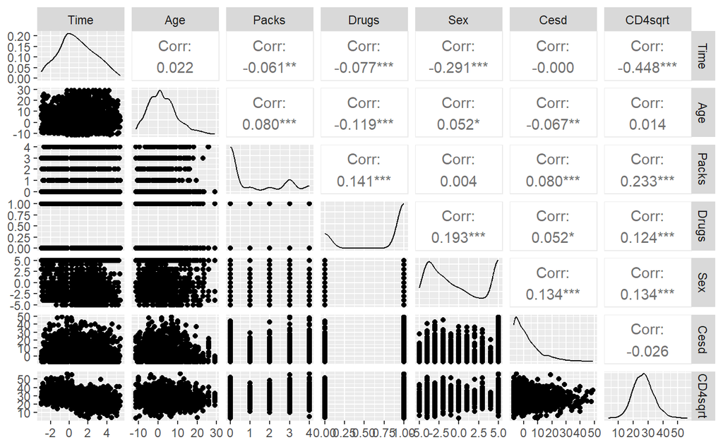

```r
ggpairs(data = data[,c(1, 3, 4, 5, 6,7 ,9)])
```

In the first step of exploratory data anslysis of CD4 data, we plot a pairs plot of the dataset. From the plot it can be seen that the square root of CD4 cell count is roughly normally distributed. Therefore, square root of CD4 cell count will be used as response variable in further analysis. The CD4 cell count is negatively correlated with time sand slightly positively correlated with Packs, Drugs and Sex variables.

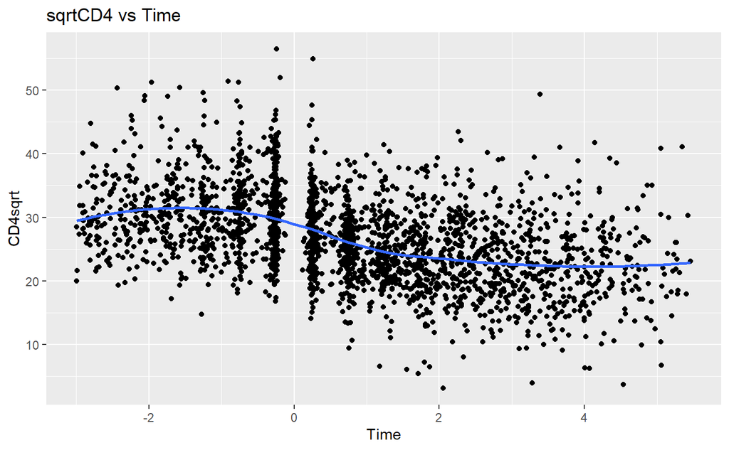

```r
p1 <- ggplot(data = data, aes(x = Time, y = CD4sqrt)) +
  geom_point() +
  geom_smooth(method = 'loess', se=FALSE) +
  ggtitle("sqrtCD4 vs Time")
print(p1)
```

The CD4+ cell number are constant until the time of seroconversion i.e. Time = 0, after that the cell number appear to be decreasing. Overall, there seems to be a decreasing trend in the CD4 cell count with time.

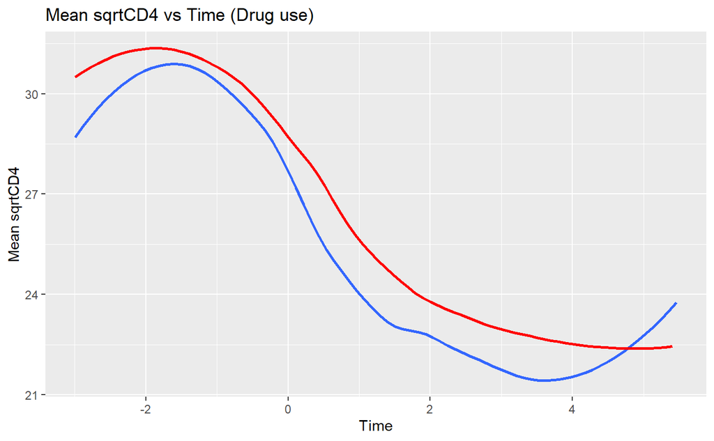

```r
df1 <- data %>% filter(Drugs==0) %>% group_by(Time) %>% summarise(mean_cd4 = mean(CD4sqrt))
df2 <- data %>% filter(Drugs==1) %>% group_by(Time) %>% summarise(mean_cd4 = mean(CD4sqrt))

p1 <- ggplot() + geom_smooth(data = df1, aes(x = Time, y = mean_cd4), method=
                               "loess", se=FALSE) +
  geom_smooth(data = df2, aes(x = Time, y = mean_cd4), method="loess", se=FALSE, color="red") + ggtitle("Mean sqrtCD4 vs Time (Drug use)") + ylab("Mean sqrtCD4")
plot(p1)
```

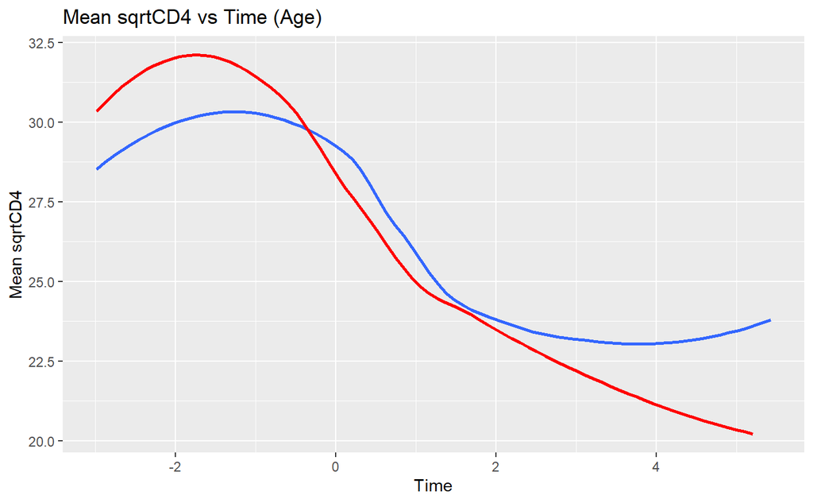

```r
df1 <- data %>% filter(Age <= quantile(data$Age, 0.25)) %>% group_by(Time) %>% summarise(mean_cd4 = mean(CD4sqrt))
df2 <- data %>% filter(Age >= quantile(data$Age, 0.75)) %>% group_by(Time) %>% summarise(mean_cd4 = mean(CD4sqrt))

p2 <- ggplot() + geom_smooth(data = df1, aes(x = Time, y = mean_cd4), method=
                               "loess", se=FALSE) +
  geom_smooth(data = df2, aes(x = Time, y = mean_cd4), method="loess", se=FALSE, color="red") + ggtitle("Mean sqrtCD4 vs Time (Age)") + ylab("Mean sqrtCD4")
plot(p2)
```

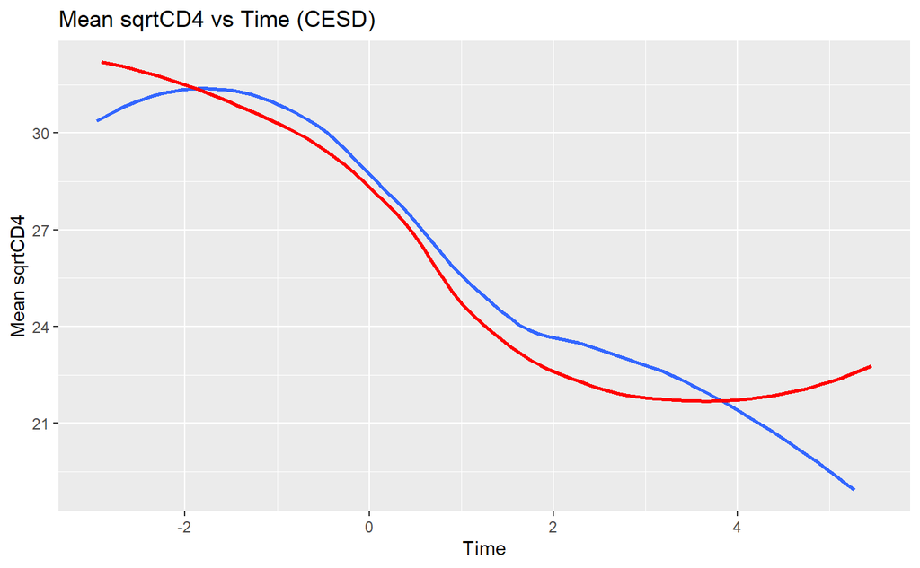

```r
df1 <- data %>% filter(Cesd <= quantile(data$Cesd, 0.25)) %>% group_by(Time) %>% summarise(mean_cd4 = mean(CD4sqrt))
df2 <- data %>% filter(Cesd >= quantile(data$Cesd, 0.75)) %>% group_by(Time) %>% summarise(mean_cd4 = mean(CD4sqrt))

p3 <- ggplot() + geom_smooth(data = df1, aes(x = Time, y = mean_cd4), method=
                               "loess", se=FALSE) +
  geom_smooth(data = df2, aes(x = Time, y = mean_cd4), method="loess", se=FALSE, color="red") + ggtitle("Mean sqrtCD4 vs Time (CESD)") + ylab("Mean sqrtCD4")
plot(p3)
```

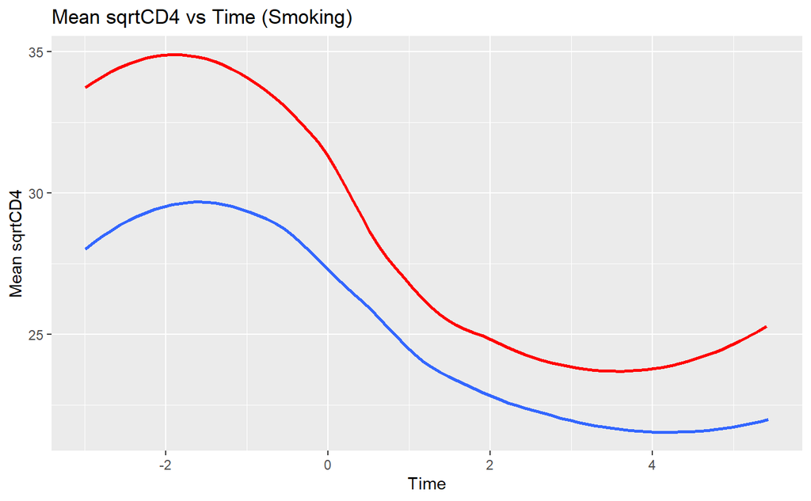

```r
df1 <- data %>% filter(Packs <= quantile(data$Packs, 0.25)) %>% group_by(Time) %>% summarise(mean_cd4 = mean(CD4sqrt))
df2 <- data %>% filter(Packs >= quantile(data$Packs, 0.75)) %>% group_by(Time) %>% summarise(mean_cd4 = mean(CD4sqrt))

p4 <- ggplot() + geom_smooth(data = df1, aes(x = Time, y = mean_cd4), method=
                               "loess", se=FALSE) +
  geom_smooth(data = df2, aes(x = Time, y = mean_cd4), method="loess", se=FALSE, color="red") + ggtitle("Mean sqrtCD4 vs Time (Smoking)") + ylab("Mean sqrtCD4")
plot(p4)
```

There seems to be a clear gap in the mean responses of CD4 cell count when stratified by drug use and smoking. Age and Cesd index seems to have no effect on the CD4 cell count. The effects of these variables will be studied in the preliminary models discussed in the next section.

# Model Formulation

To start with the model selection and analysis, we use the full model with seven knots as given in Zeger and Diggle (1994). According to the fit of the full model, the Age and Sex variables are not significant at 5% level of significance. Therefore, in further models, these variables are excluded. The full model is further simplified to decrease the number of knots and one model with no knots. The following preliminary models are considered: 1. Full model with all the variables and seven knots at equal intervals 2. Model with variables: smoking, Cest index, Drug and time, with two knots at T=0,2 3. Model with variables: Smoking, Cest index, Drug and time 4. Model with variables: Smoking, Cest index, Drug and time with one knot at T=0

```r
# Full model with 7 knots
Time.range <- range(data$Time)
n.knots <- 7
knot.spacing <- diff(Time.range)/(n.knots+1)
Time.knots <- seq(Time.range[1], Time.range[2], knot.spacing)[-c(1,(n.knots+2))]
model1 <- lm(CD4sqrt ~ ns(Time,knots = Time.knots) +
               Age + Packs + Drugs + Cesd + Sex, data = data)
summary(model1)
```

```
Call:
lm(formula = CD4sqrt ~ ns(Time, knots = Time.knots) + Age + Packs +
    Drugs + Cesd + Sex, data = data)

Residuals:
     Min       1Q   Median       3Q      Max
-21.6114  -4.0630  -0.3658   3.6787  27.9073

Coefficients:
                              Estimate Std. Error t value Pr(>|t|)
(Intercept)                   28.48923    0.99015  28.773  < 2e-16 ***
ns(Time, knots = Time.knots)1  1.73131    1.01469   1.706 0.088093 .
ns(Time, knots = Time.knots)2 -1.33323    1.24070  -1.075 0.282675
ns(Time, knots = Time.knots)3 -7.48983    1.12018  -6.686 2.85e-11 ***
ns(Time, knots = Time.knots)4 -5.37926    1.25476  -4.287 1.88e-05 ***
ns(Time, knots = Time.knots)5 -8.83823    1.29540  -6.823 1.13e-11 ***
ns(Time, knots = Time.knots)6 -7.57203    1.28978  -5.871 4.95e-09 ***
ns(Time, knots = Time.knots)7 -6.57307    2.43105  -2.704 0.006904 **
ns(Time, knots = Time.knots)8 -7.62267    1.60599  -4.746 2.19e-06 ***
Age                            0.01425    0.01672   0.852 0.394178
Packs                          0.97954    0.08744  11.202  < 2e-16 ***
Drugs                          1.07019    0.29855   3.585 0.000344 ***
Cesd                          -0.03149    0.01306  -2.411 0.015990 *
Sex                           -0.06480    0.03687  -1.757 0.078973 .
---
Signif. codes:  0 ‘***’ 0.001 ‘**’ 0.01 ‘*’ 0.05 ‘.’ 0.1 ‘ ’ 1

Residual standard error: 5.992 on 2362 degrees of freedom
Multiple R-squared:  0.2836,    Adjusted R-squared:  0.2797
F-statistic: 71.93 on 13 and 2362 DF,  p-value: < 2.2e-16
```

```r
# Model with two knots at Time = 0 and Time = 2 and excluding Age and Sex
model2 <- lm(CD4sqrt ~ ns(Time,knots = c(0, 2)) +
               Packs + Drugs + Cesd, data = data)
summary(model2)
```

```
Call:
lm(formula = CD4sqrt ~ ns(Time, knots = c(0, 2)) + Packs + Drugs +
    Cesd, data = data)

Residuals:
     Min       1Q   Median       3Q      Max
-21.5088  -4.1725  -0.3998   3.6650  27.5289

Coefficients:
                            Estimate Std. Error t value Pr(>|t|)
(Intercept)                 29.60983    0.59040  50.153  < 2e-16 ***
ns(Time, knots = c(0, 2))1 -11.01264    0.54766 -20.109  < 2e-16 ***
ns(Time, knots = c(0, 2))2  -8.46797    1.33067  -6.364 2.36e-10 ***
ns(Time, knots = c(0, 2))3  -6.93444    0.72026  -9.628  < 2e-16 ***
Packs                        0.98861    0.08726  11.329  < 2e-16 ***
Drugs                        0.90793    0.29268   3.102  0.00194 **
Cesd                        -0.03672    0.01296  -2.832  0.00466 **
---
Signif. codes:  0 ‘***’ 0.001 ‘**’ 0.01 ‘*’ 0.05 ‘.’ 0.1 ‘ ’ 1

Residual standard error: 6.029 on 2369 degrees of freedom
Multiple R-squared:  0.2725,    Adjusted R-squared:  0.2707
F-statistic: 147.9 on 6 and 2369 DF,  p-value: < 2.2e-16
```

```r
# Model with four predictor variables
model3 <- lm(CD4sqrt ~ Time + Packs + Drugs + Cesd, data = data)
summary(model3)
```

```
Call:
lm(formula = CD4sqrt ~ Time + Packs + Drugs + Cesd, data = data)

Residuals:
     Min       1Q   Median       3Q      Max
-22.8547  -4.3227  -0.3596   3.7071  27.1698

Coefficients:
            Estimate Std. Error t value Pr(>|t|)
(Intercept) 26.39302    0.27143  97.236  < 2e-16 ***
Time        -1.62056    0.06716 -24.130  < 2e-16 ***
Packs        0.98887    0.08853  11.170  < 2e-16 ***
Drugs        1.05924    0.29627   3.575 0.000357 ***
Cesd        -0.03364    0.01316  -2.557 0.010610 *
---
Signif. codes:  0 ‘***’ 0.001 ‘**’ 0.01 ‘*’ 0.05 ‘.’ 0.1 ‘ ’ 1

Residual standard error: 6.121 on 2371 degrees of freedom
Multiple R-squared:  0.2495,    Adjusted R-squared:  0.2482
F-statistic: 197.1 on 4 and 2371 DF,  p-value: < 2.2e-16
```

```r
# Piecewise linear model
data$Timesp <- data$Time*(data$Time >= 0)
model4 <- lm(CD4sqrt ~ Time + Timesp + Packs + Drugs + Cesd, data = data)
summary(model4)
```

```
Call:
lm(formula = CD4sqrt ~ Time + Timesp + Packs + Drugs + Cesd,
    data = data)

Residuals:
     Min       1Q   Median       3Q      Max
-22.8633  -4.3275  -0.3804   3.6865  27.2043

Coefficients:
            Estimate Std. Error t value Pr(>|t|)
(Intercept) 26.46469    0.32852  80.558  < 2e-16 ***
Time        -1.54844    0.19791  -7.824 7.65e-15 ***
Timesp      -0.10173    0.26259  -0.387 0.698489
Packs        0.98743    0.08862  11.142  < 2e-16 ***
Drugs        1.05307    0.29675   3.549 0.000395 ***
Cesd        -0.03370    0.01316  -2.561 0.010505 *
---
Signif. codes:  0 ‘***’ 0.001 ‘**’ 0.01 ‘*’ 0.05 ‘.’ 0.1 ‘ ’ 1

Residual standard error: 6.122 on 2370 degrees of freedom
Multiple R-squared:  0.2496,    Adjusted R-squared:  0.248
F-statistic: 157.6 on 5 and 2370 DF,  p-value: < 2.2e-16
```

```r
# Comparing the models
AIC(model1, model2, model3, model4)
```

|  | df | AIC |
| --- | --- | --- |
| model1 | 15 | 15266.79 |
| model2 | 8 | 15289.26 |
| model3 | 6 | 15359.30 |
| model4 | 7 | 15361.15 |

The full model with seven knots is slightly better performing model among all the models considered. The model with four variables is better performing than the model with one knot at Time=0. We will choose model with four variables: Time, Smoking, Drugs and Cesd for further analysis as there is not much difference in all the models considered.

The coefficients for Time and Cesd are negative, which means that CD4 cell count is decreasing over time and with increasing Cesd score. The coefficients for Packs and Drugs is positive, which means that the cell count is increasing with increased smoking and drug use.

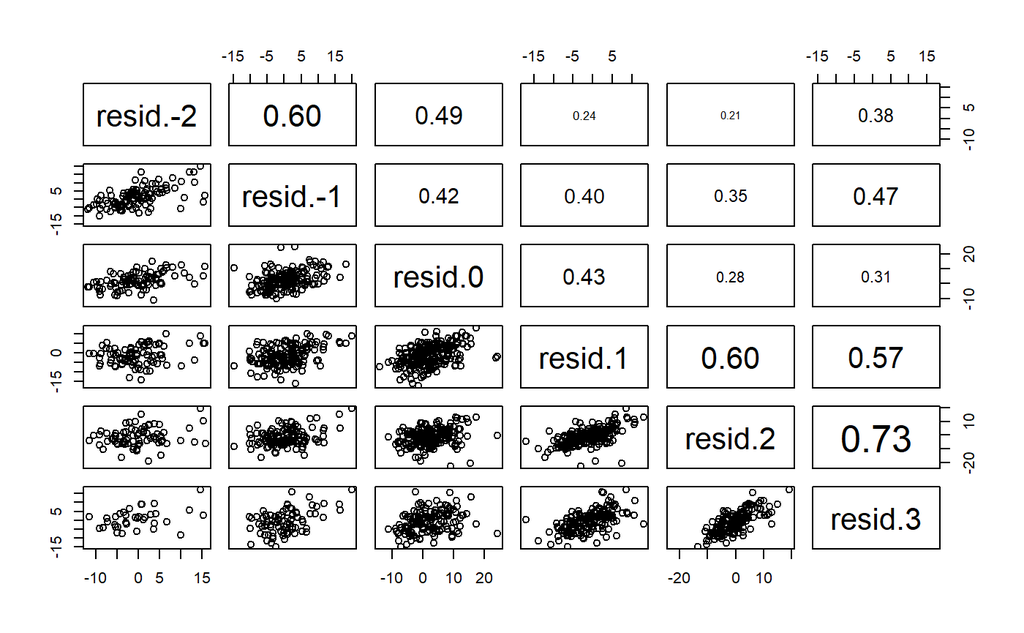

```r
# Model 3 residuals
data$resid <- resid(model3)
data$yr <- round(data$Time)
panel.cor <- function(x, y, digits = 2, prefix = "", cex.cor) {
  usr <- par("usr"); on.exit(par(usr))
  par(usr = c(0, 1, 0, 1))
  r <- abs(cor(x, y, use = "pairwise.complete.obs"))
  txt <- format(c(r, 0.123456789), digits=digits)[1]
  txt <- paste(prefix, txt, sep="")
  if(missing(cex.cor)) cex <- 0.8/strwidth(txt)
  text(0.5, 0.5, txt, cex = cex * r)
}
data.wide <- reshape(data[,c("ID", "resid", "yr")],
  direction = "wide", v.names = "resid",
  timevar = "yr", idvar = "ID")
pairs(data.wide[,c(5, 2, 3, 6:8)], upper.panel = panel.cor)
```

The correlation is decreasing for the observations that are further apart in time.

```r
# Variogram
vijk <- by(data, data$ID, function(df) {
  v <- outer(df$resid, df$resid,
  function(x, y) 0.5*(x-y)^2)
  v[lower.tri(v)]
})

uijk <- by(data, data$ID, function(df) {
  u <- outer(df$Time, df$Time,
  function(x, y) abs(x - y))
  u[lower.tri(u)]
})

uijk <- unlist(uijk)
vijk <- unlist(vijk)

vu.lowess <- lowess(uijk, vijk)
sigma2 <- var(data$resid)

plot(uijk, vijk, col = "gray50", pch = 18, cex = 0.4,
  xlim = c(0, 6), ylim = c(0, 150),
  xlab = "Lag", ylab = "Half squared differences")
lines(vu.lowess, col = "red", lwd = 2)
```

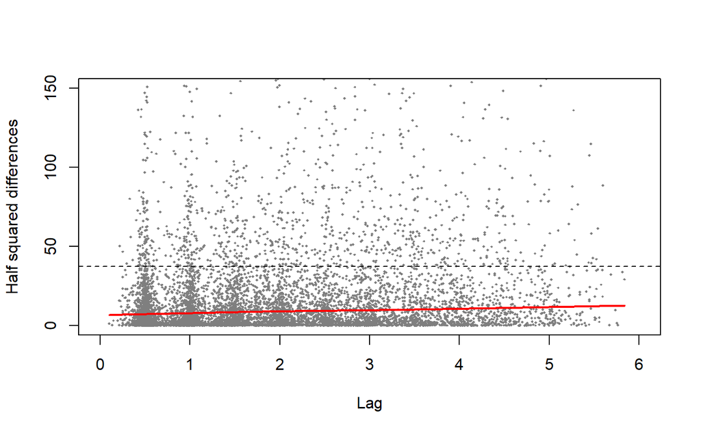

```r
abline(h = sigma2, lty = 2)
```

The variogram is increasing with increase in lag, which also shows that the correlation is decreasing when observations are further apart in time.

Further in the analysis, we fit model with different covariance structures for patients and evaluate the fit. The following models are considered: 1. Model with compound symmetry covariance structure. 2. Model with unequal variances for each patient. 3. Model with exponential covariance structure. 4. Model with Gaussian covariance structure.

```r
data <- data %>% group_by(ID) %>%
            mutate(obsnum = seq_along(ID)) %>%
            ungroup()
```

```r
# Compound Symmetry
modcov.cc <- gls(CD4sqrt ~ Time + Packs + Drugs + Cesd,
                    correlation = corCompSymm(form = ~ obsnum | ID),
                    weights = varIdent(form = ~ 1 | obsnum),
                    data = data)
summary(modcov.cc)
```

```
Generalized least squares fit by REML
  Model: CD4sqrt ~ Time + Packs + Drugs + Cesd
  Data: data
```

|  | AIC | BIC | logLik |
| --- | --- | --- | --- |
|  | 14539.95 | 14643.83 | -7251.975 |

```
Correlation Structure: Compound symmetry
 Formula: ~obsnum | ID
 Parameter estimate(s):
      Rho
0.4758357
Variance function:
 Structure: Different standard deviations per stratum
 Formula: ~1 | obsnum
 Parameter estimates:
        1         2         3         4         5         6         7         8         9
1.0000000 0.9989189 0.9121358 0.8733041 0.9362017 0.8944669 1.0345826 0.9005783 0.8904452
       10        11        12
0.8621777 0.7976792 1.0466554

Coefficients:
```

|  | Value | Std.Error | t-value | p-value |
| --- | --- | --- | --- | --- |
| (Intercept) | 27.038981 | 0.3721565 | 72.65486 | 0.0000 |
| Time | -1.825126 | 0.0600462 | -30.39536 | 0.0000 |
| Packs | 0.572336 | 0.1242442 | 4.60655 | 0.0000 |
| Drugs | 0.668650 | 0.3157762 | 2.11748 | 0.0343 |
| Cesd | -0.042331 | 0.0140777 | -3.00692 | 0.0027 |

```
 Correlation:
      (Intr) Time   Packs  Drugs
Time  -0.282
Packs -0.334  0.102
Drugs -0.653  0.143 -0.037
Cesd  -0.057 -0.036 -0.050 -0.025

Standardized residuals:
        Min          Q1         Med          Q3         Max
-3.44556215 -0.67197806 -0.04031691  0.64624160  4.11240860

Residual standard error: 6.514998
Degrees of freedom: 2376 total; 2371 residual
```

```r
# Unequal variances
modcov.uv <- gls(CD4sqrt ~ Time + Packs + Drugs + Cesd,
                    weights = varIdent(form = ~ 1 | obsnum),
                    data = data)
summary(modcov.uv)
```

```
Generalized least squares fit by REML
  Model: CD4sqrt ~ Time + Packs + Drugs + Cesd
  Data: data
```

|  | AIC | BIC | logLik |
| --- | --- | --- | --- |
|  | 15383.13 | 15481.24 | -7674.565 |

```
Variance function:
 Structure: Different standard deviations per stratum
 Formula: ~1 | obsnum
 Parameter estimates:
        1         2         3         4         5         6         7         8         9
1.0000000 1.0727986 0.9992171 0.9769281 1.0447505 1.0050502 1.1722716 1.0497711 1.0173458
       10        11        12
0.9978562 0.8054113 0.9607609

Coefficients:
```

|  | Value | Std.Error | t-value | p-value |
| --- | --- | --- | --- | --- |
| (Intercept) | 26.430752 | 0.26973153 | 97.98911 | 0e+00 |
| Time | -1.605618 | 0.06617356 | -24.26374 | 0e+00 |
| Packs | 0.986334 | 0.08814247 | 11.19022 | 0e+00 |
| Drugs | 1.012360 | 0.29436124 | 3.43918 | 6e-04 |
| Cesd | -0.034104 | 0.01303650 | -2.61602 | 9e-03 |

```
 Correlation:
      (Intr) Time   Packs  Drugs
Time  -0.277
Packs -0.215  0.057
Drugs -0.791  0.068 -0.133
Cesd  -0.065 -0.007 -0.071 -0.038

Standardized residuals:
       Min         Q1        Med         Q3        Max
-3.6747546 -0.7037005 -0.0605009  0.6007536  4.0328992

Residual standard error: 5.953535
Degrees of freedom: 2376 total; 2371 residual
```

```r
# Exponential covariance structure
modcov.exp <- gls(CD4sqrt ~ Time + Packs + Drugs + Cesd,
                    correlation = corExp(form = ~ obsnum | ID),
                    data = data)
summary(modcov.exp)
```

```
Generalized least squares fit by REML
  Model: CD4sqrt ~ Time + Packs + Drugs + Cesd
  Data: data
```

|  | AIC | BIC | logLik |
| --- | --- | --- | --- |
|  | 14483.12 | 14523.51 | -7234.558 |

```
Correlation Structure: Exponential spatial correlation
 Formula: ~obsnum | ID
 Parameter estimate(s):
   range
2.076815

Coefficients:
```

|  | Value | Std.Error | t-value | p-value |
| --- | --- | --- | --- | --- |
| (Intercept) | 26.820713 | 0.3481686 | 77.03369 | 0.0000 |
| Time | -1.710301 | 0.0887335 | -19.27458 | 0.0000 |
| Packs | 0.623111 | 0.1203686 | 5.17669 | 0.0000 |
| Drugs | 0.775847 | 0.3152912 | 2.46073 | 0.0139 |
| Cesd | -0.045172 | 0.0136324 | -3.31359 | 0.0009 |

```
 Correlation:
      (Intr) Time   Packs  Drugs
Time  -0.255
Packs -0.315  0.064
Drugs -0.666  0.059 -0.069
Cesd  -0.072 -0.018 -0.020 -0.032

Standardized residuals:
        Min          Q1         Med          Q3         Max
-3.42321092 -0.65783821 -0.04535101  0.63170914  4.38551420

Residual standard error: 6.215988
Degrees of freedom: 2376 total; 2371 residual
```

```r
# Gaussian covariance structure
modcov.gaus <- gls(CD4sqrt ~ Time + Packs + Drugs + Cesd,
                    correlation = corGaus(form = ~ obsnum | ID),
                    data = data)
summary(modcov.gaus)
```

```
Generalized least squares fit by REML
  Model: CD4sqrt ~ Time + Packs + Drugs + Cesd
  Data: data
```

|  | AIC | BIC | logLik |
| --- | --- | --- | --- |
|  | 14754.09 | 14794.48 | -7370.044 |

```
Correlation Structure: Gaussian spatial correlation
 Formula: ~obsnum | ID
 Parameter estimate(s):
   range
1.092712

Coefficients:
```

|  | Value | Std.Error | t-value | p-value |
| --- | --- | --- | --- | --- |
| (Intercept) | 26.656128 | 0.30206891 | 88.24519 | 0.0000 |
| Time | -1.636123 | 0.07916344 | -20.66766 | 0.0000 |
| Packs | 0.822431 | 0.10352092 | 7.94459 | 0.0000 |
| Drugs | 0.811767 | 0.30598264 | 2.65299 | 0.0080 |
| Cesd | -0.040964 | 0.01334051 | -3.07066 | 0.0022 |

```
 Correlation:
      (Intr) Time   Packs  Drugs
Time  -0.273
Packs -0.271  0.057
Drugs -0.735  0.057 -0.102
Cesd  -0.064 -0.014 -0.044 -0.041

Standardized residuals:
        Min          Q1         Med          Q3         Max
-3.71831550 -0.70299663 -0.05150864  0.64042211  4.56767122

Residual standard error: 5.946794
Degrees of freedom: 2376 total; 2371 residual
```

```r
# comparing models
AIC(model1, model3, modcov.cc, modcov.uv, modcov.exp, modcov.gaus)
```

|  | df | AIC |
| --- | --- | --- |
| model1 | 15 | 15266.79 |
| model3 | 6 | 15359.30 |
| modcov.cc | 18 | 14539.95 |
| modcov.uv | 17 | 15383.13 |
| modcov.exp | 7 | 14483.12 |
| modcov.gaus | 7 | 14754.09 |

Now, we will consider adding random effects to the fixed effects already modeled previously. The random effect models include random effect for time variable. The following models are considered: 1. Random effect for Time with no correlation structure. 2. Random effect for Time with exponential correlation structure. 3. Random effect for Time with Gaussian correlation structure.

```r
# Random effect model
mod.rand1 <- lme(CD4sqrt ~ Time + Packs + Drugs + Cesd,
                 random  = ~ Time | ID,
                 data = data)

summary(mod.rand1)
```

```
Linear mixed-effects model fit by REML
  Data: data
```

|  | AIC | BIC | logLik |
| --- | --- | --- | --- |
|  | 14353.42 | 14405.36 | -7167.712 |

```
Random effects:
 Formula: ~Time | ID
 Structure: General positive-definite, Log-Cholesky parametrization
            StdDev   Corr
(Intercept) 4.054728 (Intr)
Time        1.410589 -0.015
Residual    3.923961

Fixed effects:  CD4sqrt ~ Time + Packs + Drugs + Cesd
```

|  | Value | Std.Error | DF | t-value | p-value |
| --- | --- | --- | --- | --- | --- |
| (Intercept) | 27.015892 | 0.3624728 | 2003 | 74.53219 | 0.0000 |
| Time | -2.025114 | 0.0986074 | 2003 | -20.53713 | 0.0000 |
| Packs | 0.564487 | 0.1207910 | 2003 | 4.67325 | 0.0000 |
| Drugs | 0.827629 | 0.3122577 | 2003 | 2.65047 | 0.0081 |
| Cesd | -0.041709 | 0.0137568 | 2003 | -3.03190 | 0.0025 |

```
 Correlation:
      (Intr) Time   Packs  Drugs
Time  -0.121
Packs -0.327  0.052
Drugs -0.658  0.084 -0.056
Cesd  -0.075 -0.022 -0.035 -0.014

Standardized Within-Group Residuals:
        Min          Q1         Med          Q3         Max
-4.47682390 -0.54045302 -0.01859626  0.52758673  5.19025101

Number of Observations: 2376
Number of Groups: 369
```

```r
# Random effect model with Gaussian correlation structure
mod.gau.rand <- lme(CD4sqrt ~ Time + Packs + Drugs + Cesd,
                    random= ~ Time | ID, corr=corGaus(, form= ~ Time | ID,nugget=TRUE,value=c(2,.1)),
data=data)
summary(mod.gau.rand)
```

```
Linear mixed-effects model fit by REML
  Data: data
```

|  | AIC | BIC | logLik |
| --- | --- | --- | --- |
|  | 14316.2 | 14379.69 | -7147.102 |

```
Random effects:
 Formula: ~Time | ID
 Structure: General positive-definite, Log-Cholesky parametrization
            StdDev   Corr
(Intercept) 3.706609 (Intr)
Time        1.143530 0.103
Residual    4.325091

Correlation Structure: Gaussian spatial correlation
 Formula: ~Time | ID
 Parameter estimate(s):
   range   nugget
1.038160 0.653352
Fixed effects:  CD4sqrt ~ Time + Packs + Drugs + Cesd
```

|  | Value | Std.Error | DF | t-value | p-value |
| --- | --- | --- | --- | --- | --- |
| (Intercept) | 26.892608 | 0.3594958 | 2003 | 74.80647 | 0.0000 |
| Time | -1.949959 | 0.0947370 | 2003 | -20.58286 | 0.0000 |
| Packs | 0.614307 | 0.1214953 | 2003 | 5.05622 | 0.0000 |
| Drugs | 0.765592 | 0.3140921 | 2003 | 2.43748 | 0.0149 |
| Cesd | -0.039997 | 0.0136915 | 2003 | -2.92132 | 0.0035 |

```
 Correlation:
      (Intr) Time   Packs  Drugs
Time  -0.102
Packs -0.327  0.050
Drugs -0.659  0.074 -0.060
Cesd  -0.073 -0.022 -0.028 -0.021

Standardized Within-Group Residuals:
        Min          Q1         Med          Q3         Max
-3.52108594 -0.52478248 -0.02275588  0.50607553  4.99764597

Number of Observations: 2376
Number of Groups: 369
```

```r
# Random effect model with exponential correlation structure
mod.exp.rand <- lme(CD4sqrt ~ Time + Packs + Drugs + Cesd,
                    random= ~ Time | ID, corr=corExp(, form= ~ Time | ID,nugget=TRUE,value=c(2,.1)),
data=data)
summary(mod.exp.rand)
```

```
Linear mixed-effects model fit by REML
  Data: data
```

|  | AIC | BIC | logLik |
| --- | --- | --- | --- |
|  | 14316.87 | 14380.35 | -7147.433 |

```
Random effects:
 Formula: ~Time | ID
 Structure: General positive-definite, Log-Cholesky parametrization
            StdDev   Corr
(Intercept) 3.664360 (Intr)
Time        1.134567 0.111
Residual    4.368432

Correlation Structure: Exponential spatial correlation
 Formula: ~Time | ID
 Parameter estimate(s):
    range    nugget
0.7464445 0.4419718
Fixed effects:  CD4sqrt ~ Time + Packs + Drugs + Cesd
```

|  | Value | Std.Error | DF | t-value | p-value |
| --- | --- | --- | --- | --- | --- |
| (Intercept) | 26.898965 | 0.3595452 | 2003 | 74.81386 | 0.0000 |
| Time | -1.949248 | 0.0948206 | 2003 | -20.55722 | 0.0000 |
| Packs | 0.610585 | 0.1217057 | 2003 | 5.01690 | 0.0000 |
| Drugs | 0.762190 | 0.3138475 | 2003 | 2.42854 | 0.0152 |
| Cesd | -0.040034 | 0.0137158 | 2003 | -2.91881 | 0.0036 |

```
 Correlation:
      (Intr) Time   Packs  Drugs
Time  -0.102
Packs -0.327  0.051
Drugs -0.659  0.074 -0.060
Cesd  -0.073 -0.022 -0.029 -0.020

Standardized Within-Group Residuals:
        Min          Q1         Med          Q3         Max
-3.50361577 -0.52810882 -0.02202447  0.51411771  4.96599726

Number of Observations: 2376
Number of Groups: 369
```

```r
# Comparing models
AIC(mod.exp.rand, mod.gau.rand, mod.rand1)
```

|  | df | AIC |
| --- | --- | --- |
| mod.exp.rand | 11 | 14316.87 |
| mod.gau.rand | 11 | 14316.20 |
| mod.rand1 | 9 | 14353.42 |

```r
# Final model
mod <- lme(CD4sqrt ~ Time + Packs + Drugs + Cesd,
                    random= ~ Time | ID, corr=corGaus(, form= ~ Time | ID,nugget=TRUE,value=c(2,.1)),
data=data)
summary(mod)
```

```
Linear mixed-effects model fit by REML
  Data: data
```

|  | AIC | BIC | logLik |
| --- | --- | --- | --- |
|  | 14316.2 | 14379.69 | -7147.102 |

```
Random effects:
 Formula: ~Time | ID
 Structure: General positive-definite, Log-Cholesky parametrization
            StdDev   Corr
(Intercept) 3.706609 (Intr)
Time        1.143530 0.103
Residual    4.325091

Correlation Structure: Gaussian spatial correlation
 Formula: ~Time | ID
 Parameter estimate(s):
   range   nugget
1.038160 0.653352
Fixed effects:  CD4sqrt ~ Time + Packs + Drugs + Cesd
```

|  | Value | Std.Error | DF | t-value | p-value |
| --- | --- | --- | --- | --- | --- |
| (Intercept) | 26.892608 | 0.3594958 | 2003 | 74.80647 | 0.0000 |
| Time | -1.949959 | 0.0947370 | 2003 | -20.58286 | 0.0000 |
| Packs | 0.614307 | 0.1214953 | 2003 | 5.05622 | 0.0000 |
| Drugs | 0.765592 | 0.3140921 | 2003 | 2.43748 | 0.0149 |
| Cesd | -0.039997 | 0.0136915 | 2003 | -2.92132 | 0.0035 |

```
 Correlation:
      (Intr) Time   Packs  Drugs
Time  -0.102
Packs -0.327  0.050
Drugs -0.659  0.074 -0.060
Cesd  -0.073 -0.022 -0.028 -0.021

Standardized Within-Group Residuals:
        Min          Q1         Med          Q3         Max
-3.52108594 -0.52478248 -0.02275588  0.50607553  4.99764597

Number of Observations: 2376
Number of Groups: 369
```

Comparing the AIC values for all the models considered so far, we can say that the random effect model with Gaussian correlation structure is a better model. The Gaussian correlation structure model with random effects can also be written as:

$$sqrtCD4 = β_1 + β_2 \times Time + β_3 × Packs + β_4 × Drugs + β_5 × Cesd
+ b_1 + b_2 \times Time$$

### Application to Individual Trajectories

A patient was selected from the CD4 data, with measurement spread roughly evenly over Time = 0.

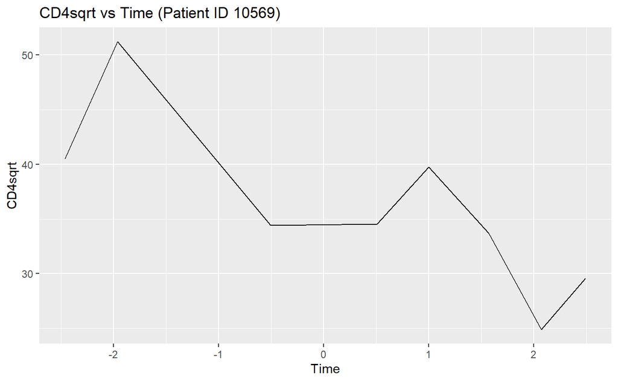

```r
# find patient
selected <- data %>%
  filter((Time <= -1.5 & obsnum >= 3) | (Time >= 1.5 & obsnum >= 6))

IDs <- unique(selected$ID)
sel.data <- data %>% filter(ID %in% IDs)

ggplot(data = sel.data[sel.data$ID==10569,], aes(x=Time, y = CD4sqrt)) +
  geom_line() +
  ggtitle("CD4sqrt vs Time (Patient ID 10569)")
```

```r
# Covariance matrix
covmat <- getVarCov(mod, individual = "10569", type = 'marginal')
cormat <- round(cov2cor(covmat$"10569"), 3)
cormat
```

```
      1     2     3     4     5     6     7     8
1 1.000 0.630 0.406 0.316 0.272 0.220 0.177 0.142
2 0.630 1.000 0.437 0.343 0.306 0.262 0.224 0.194
3 0.406 0.437 1.000 0.485 0.421 0.384 0.364 0.349
4 0.316 0.343 0.485 1.000 0.597 0.512 0.465 0.448
5 0.272 0.306 0.421 0.597 1.000 0.606 0.539 0.503
6 0.220 0.262 0.384 0.512 0.606 1.000 0.644 0.593
7 0.177 0.224 0.364 0.465 0.539 0.644 1.000 0.678
8 0.142 0.194 0.349 0.448 0.503 0.593 0.678 1.000
```

From the correlation matrix for the selected patient, we can see that the correlation is decreasing with time of observation.

Next, we select three patients using the same criteria. We use the Best Linear Unbiased Predictor (BLUP) and the chosen model to predict the individual trajectories.

```r
# BLUP
patient1 <- subset(data, ID == 10569)
patient2 <- subset(data, ID == 11172)
patient3 <- subset(data, ID == 20363)

plot(CD4sqrt~Time,data=patient1,pch=4, col="red",xlim=c(-3,3),xlab="Time",ylab="sqrtCD4")
points(CD4sqrt~Time,data=patient2,pch=3, col="blue")
```

```r
points(CD4sqrt~Time,data=patient3,pch=3, col="green")

t3 <- seq(-3,3,0.01)
t2 <- seq(-3,3,0.01)
t1 <- seq(-3,3,0.01)
t0 <- seq(-3,3,0.01)
incpt<-rep(1,length(t1))
X<-cbind(incpt,t3,t2,t1,t0)
incpt<- cbind(incpt, t0)

pmean<-X%*%mod$coefficients$fixed

lines(t1,pmean,lty=1,lwd=3)
```

```r
l1<-incpt%*%mod$coefficients$random$ID["10569",]+pmean
lines(t1,l1,col="red",lty=1,lwd=2)

l2<-incpt%*%mod$coefficients$random$ID["11172",]+pmean
lines(t1,l2,col="blue",lty=1,lwd=2)
```

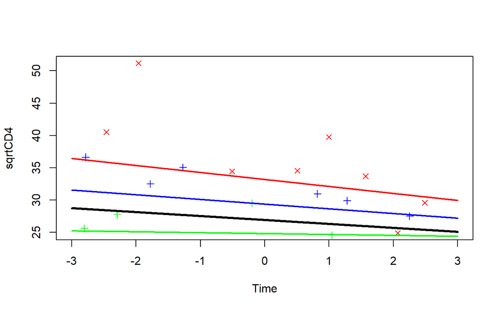

```r
l3<-incpt%*%mod$coefficients$random$ID["20363",]+pmean
lines(t1,l3,col="green",lty=1,lwd=2)
```

The observed level of CD4 cell counts are also shown on the plot. As the random effect model has random intercept as well as random slope for time, which is shown in the separate trajectories.

The models including random effects and different correlation structures were analysed next. A model with random effect on time and Gaussian correlation structure was found to be better than all the models considered previously.